# 第2次实践 参数估计

### 实验一

设 $X_1,X_2,\ldots X_n$ 为来自均匀分布总体 $X\sim U(a,b)$ 的样本，求未知参数 $a,b$ 的点估计.

```r
# 样本方差
sample_deviation <- function(sample_set) {
    s <- 0
    ave <- mean(sample_set)
    n <- length(sample_set)
    for (i in sample_set) {
        s <- s + (i - ave)^2
    }
    return(s / (n - 1))
}
# 矩估计
moment_estimate <- function(a, b, n, v) {
    sample_set <- runif(n, a, b)
    ave <- mean(sample_set)
    if (v == "a") {
        return(ave - sqrt(3 * sample_deviation(sample_set)))
    }
    if (v == "b") {
        return(ave + sqrt(3 * sample_deviation(sample_set)))
    }
}
a <- 0
b <- 1
n <- 500
```

```r
cat("a 的矩估计", moment_estimate(a, b, n, "a"))
```

```
## a 的矩估计 -0.01252088
```

```r
cat("b 的矩估计", moment_estimate(a, b, n, "b"))
```

```
## b 的矩估计 1.011432
```

(2). 将(1)重复10次,用10次估计值的平均值作为 $a,b$ 的估计,并与(1)的结果比较,体会其中包含的概率思想.

```r
ave_a <- c()
ave_b <- c()
for (i in 1:10) {
    ave_a <- c(ave_a, moment_estimate(a, b, n, "a"))
    ave_b <- c(ave_b, moment_estimate(a, b, n, "b"))
}
cat("a 的均值", mean(ave_a))
```

```
## a 的均值 -0.00641851
```

```r
cat("b 的均值", mean(ave_b))
```

```
## b 的均值 1.004355
```

### 实验二

设总体 $X\sim P(\lambda)(\lambda>0)$ , $X_1,X_2,\ldots X_n$ 是来自总体X的一组样本，求参数 $\lambda$ 的极大似然估计量

$$P(X=k)=\frac{\lambda^k}{k!}e^{-\lambda},k=0,1,\cdots$$

$$\left\{\begin{aligned}
& L(\lambda)=e^{-n\lambda}\prod^n_{i=1}\frac{\lambda^{x_i}}{x_i!} \\
& \frac{\text{d}lnL(\lambda)}{\text{d}\lambda}=0
\end{aligned}\right.
\quad\Rightarrow\quad
\hat{\lambda}=\overline{x}$$

```r
maximum_likelihood_estimate <- function(lambda) {
    sample_num <- 1000
    sample_set <- rpois(sample_num, lambda)
    return(mean(sample_set))
}
lambda <- 0.5
cat("λ 取值", lambda)
```

```
## λ 取值 0.5
```

```r
cat("λ 的极大似然估计", maximum_likelihood_estimate(lambda))
```

```
## λ 的极大似然估计 0.5
```

### 实验三

设总体 $X$ 的密度函数为 $f(x)=\left\{\begin{array}{c}(\theta+1) x^{\theta}, 0<x<1 \\0, \text { 其他 }\end{array}, \theta>-1\right.$ 是未知参数， $X_1,X_2,\ldots X_n$ 是来自总体 $X$ 的一组样本，求 $\theta$ 的极大似然估计量

$$F(x)=\int^{x}_{0}(\theta+1) x^{\theta}\text{d}x=x^{\theta+1} \quad\Rightarrow\quad x={F(x)}^{\frac{1}{\theta+1}}$$

$$\left\{\begin{aligned}
& L(\theta) = (\theta+1)^n (\prod^{n}_{i=1}x_i)^\theta \\
& \frac{\text{d}lnL(\theta)}{\text{d}\theta}=0
\end{aligned}\right.
\quad \Rightarrow \quad
\hat{\theta} = -\frac{n}{\sum^{n}_{i=1}lnx_i}-1$$

```r
maximum_likelihood_estimate <- function(theta) {
    sample_num <- 1000
    sample_set <- log(runif(sample_num, 0, 1)^(1 / (theta + 1)))
    return(-sample_num / sum(sample_set) - 1)
}
theta <- 0.5
cat("θ 取值", theta)
```

```
## θ 取值 0.5
```

```r
cat("θ 的极大似然估计", maximum_likelihood_estimate(theta))
```

```
## θ 的极大似然估计 0.4467611
```

### 实验四

随机产生随机数 $X\sim N(8,1)$ ,样本容量为9，这样的样本共100份，试求出100份样本中均值 $\mu$ 的置信水平为0.95的置信区间，并统计100个置信区间中大概有多少个区间包含真正均值 $\mu$ ，即大概有多少个区间包含总体均值8。

```
## 包含总体均值8的区间个数= 95
```

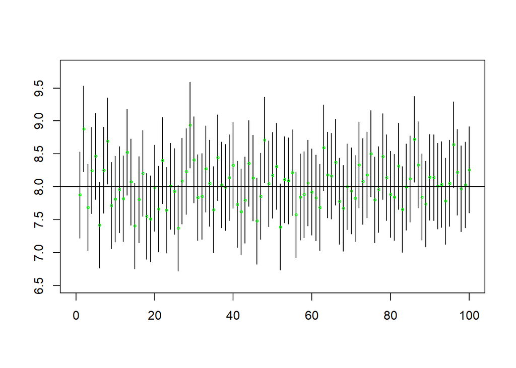

```r
m <- matrix(rnorm(900, 8, 1), 100, 9)
Mean <- apply(m, 1, mean)
low <- Mean - (1 / sqrt(9)) * qnorm(0.975)
up <- Mean + (1 / sqrt(9)) * qnorm(0.975)
CIs <- cbind(low, up)
CIlow <- apply(CIs, 1, min)
CIup <- apply(CIs, 1, max)
CIs <- data.frame(low = CIlow, up = CIup)
plot(0,
    xlim = c(0, 100), ylim = c(min(CIs) - 0.2, max(CIs) + 0.2),
    type = "n", xlab = "", ylab = ""
)
cnt <- 0
for (i in seq_len(nrow(CIs))) {
    lines(rep(i, 2), c(CIs[i, 1], CIs[i, 2]))
    points(i, Mean[i], col = "green", cex = 0.5)
    if (CIs[i, 1] <= 8 && 8 <= CIs[i, 2]) {
        cnt <- cnt + 1
    }
}
abline(h = 8)
cat("包含总体均值8的区间个数=", cnt)
```

### 实验五

已知幼儿身高服从正态分布，现从5~6岁的幼儿中随机地抽查了9人，其高度(单位：cm)分别为：115，120，131，115， 109，115，115，105，110；假设标准差 $\sigma_0=7$ ，置信度为95%，试求总体均值 $\mu$ 的置信区间.

置信区间 $[\overline{X}-\frac{\sigma}{\sqrt{n}}u_{1-\frac{\alpha}{2}},\overline{X}+\frac{\sigma}{\sqrt{n}}u_{1-\frac{\alpha}{2}}],\alpha = 0.05$

```r
n <- 9
height_set <- c(115, 120, 131, 115, 109, 115, 115, 105, 110)
sigma0 <- 7
alpha <- 0.05
ave <- mean(height_set)
u <- qnorm(1 - alpha / 2)
cat("置信区间 [", ave - u * sigma0 / sqrt(n), ",", ave + u * sigma0 / sqrt(n), "]")
```

```
## 置信区间 [ 110.4268 , 119.5732 ]
```

### 实验六

试利用R软件说明以下问题：显然对于 $N(0,1)$ 这种对称的密度函数，选取左、右两尾的面积（概率）相等对应的分位点，得到的置信区间长度最短，即估计的精度最高．但对于非对称的密度函数，选取左、右两尾的面积相等对应的分位点，得到的区间长度并非最短，但也与最小长度相差不是很大.

使用 $\chi^2$ 分布验证

```
## α= 0.005 自由度= 2 最小区间长= 10.59663 等尾原则区间长= 11.93842
## α= 0.01 自由度= 2 最小区间长= 9.21034 等尾原则区间长= 10.54721
## α= 0.025 自由度= 2 最小区间长= 7.377759 等尾原则区间长= 8.699797
## α= 0.05 自由度= 2 最小区间长= 5.991465 等尾原则区间长= 7.288543
```

```
## α= 0.005 自由度= 5 最小区间长= 16.7114 等尾原则区间长= 18.03431
## α= 0.01 自由度= 5 最小区间长= 15.02635 等尾原则区间长= 16.29426
## α= 0.025 自由度= 5 最小区间长= 12.72191 等尾原则区间长= 13.89003
## α= 0.05 自由度= 5 最小区间长= 10.89554 等尾原则区间长= 11.95929
```

```
## α= 0.005 自由度= 10 最小区间长= 24.2173 等尾原则区间长= 25.23912
## α= 0.01 自由度= 10 最小区间长= 22.03514 等尾原则区间长= 22.98713
## α= 0.025 自由度= 10 最小区间长= 18.96298 等尾原则区间长= 19.80683
## α= 0.05 自由度= 10 最小区间长= 16.44653 等尾原则区间长= 17.19322
```

```
## α= 0.005 自由度= 15 最小区间长= 29.99059 等尾原则区间长= 30.83363
## α= 0.01 自由度= 15 最小区间长= 27.37554 等尾原则区间长= 28.15475
## α= 0.025 自由度= 15 最小区间长= 23.65834 等尾原则区间长= 24.34165
## α= 0.05 自由度= 15 最小区间长= 20.5832 等尾原则区间长= 21.18304
```

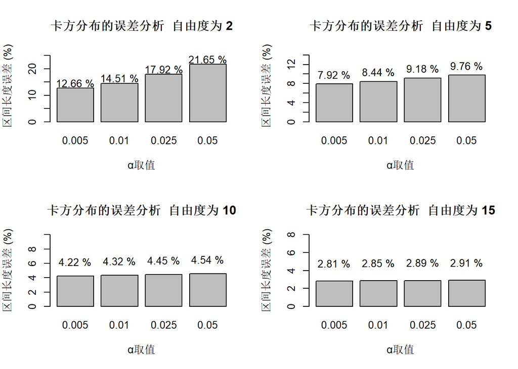

```r
# 卡方分布的误差分析
error_chisq <- function(alpha, df) {
    # 取值细度
    fineness <- 100
    # 左侧面积取值
    ls <- seq(0, alpha * (fineness - 1) / fineness, alpha / fineness)
    # 对应置信区间长度
    len <- c()
    for (i in ls) {
        left <- qchisq(i, df)
        right <- qchisq(1 - (alpha - i), df)
        len <- c(len, right - left)
    }
    cat(
        "α=", alpha, "自由度=", df,
        "最小区间长=", min(len), "等尾原则区间长=", len[fineness / 2], "\n"
    )
    # 使用等尾原则时区间长度相对最小区间长度的误差
    return(abs(len[fineness / 2] - min(len)) / (min(len)))
}
draw_chisq <- function(df) {
    alpha <- c(0.005, 0.01, 0.025, 0.05)
    e <- c()
    for (a in alpha) {
        e <- c(e, error_chisq(a, df))
    }
    e <- round(e, 6)
    error_plot <- barplot(e * 100,
        names.arg = alpha,
        ylim = c(0, ceiling(max(e * 100) + 5)),
        main = paste("卡方分布的误差分析  自由度为", df),
        xlab = "α取值", ylab = "区间长度误差 (%)"
    )
    text(error_plot, e * 100 + 2, paste(round(e * 100, 2), "%"))
}
par(mfrow = c(2, 2))
df_set <- c(2, 5, 10, 15)
for (df in df_set) {
    draw_chisq(df)
}
```

### 实验七

试利用R软件说明以下问题：当置信水平 $1-\alpha$ 固定，样本容量 $n$ 与区间精度的关系

使用单一正态总体均值的区间估计为例进行说明

$$X\sim N(0,1)$$

取置信水平 $1-\alpha = 0.95$

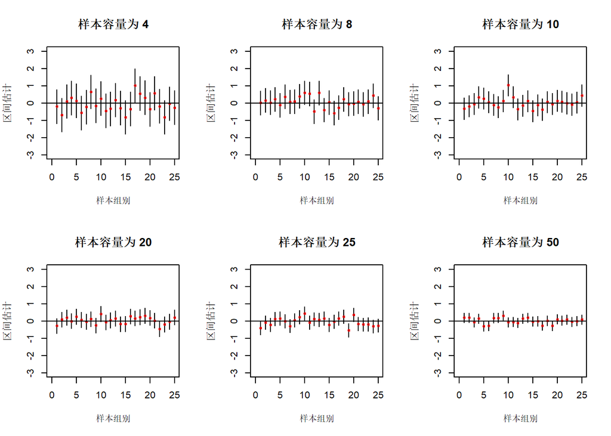

```r
confidence_interval <- function(n) {
    alpha <- 0.05
    # 样本容量为 n 的 k 组样本
    k <- 25
    sample_set <- matrix(rnorm(n * k, 0, 1), nrow = k, ncol = n)
    # 按行求均值
    sample_mean <- apply(sample_set, 1, mean)
    # 区间范围
    low <- sample_mean - (1 / sqrt(n)) * qnorm(1 - alpha / 2)
    up <- sample_mean + (1 / sqrt(n)) * qnorm(1 - alpha / 2)
    sample_confidence_interval <- cbind(low, up)
    plot(c(),
        main = paste("样本容量为", n), xlab = "样本组别", ylab = "区间估计",
        xlim = c(0, k), ylim = c(-3, 3)
    )
    for (i in 1:k) {
        lines(rep(i, 2), c(low[i], up[i]))
        points(i, sample_mean[i], col = "red", cex = 0.5)
    }
    abline(h = 0)
}
par(mfrow = c(2, 3))
n <- c(4, 8, 10, 20, 25, 50)
for (n in n) {
    confidence_interval(n)
}
```

随样本容量的增加，区间估计的范围减小，样本均值靠近总体均值，区间精度提高